# EDA for House Price Prediction

SangminJe

2021 5 21

## Data

이번 주택 데이터의 목록입니다. 미국의 주택을 기준으로 데이터를 만든 것 같은데, 한국 아파트가 더 익숙한 저로서는 익숙하지 않은 항목들이 많았습니다.  
데이터 목록을 보시기 전에 먼저 알아두시면 좋은 점은, **Quality**와 **Condition**을 구분하는 관점입니다. **Quality**는 돈을 들여서 잘 만든 수준을 이야기합니다. 예를 들어서 벽난로가 나무로 만들어진 것과 대리석으로 만들어진 것이 있다면, 대리석으로 만들어진 게 보통 **Quality**가 좋다고 생각하실 겁니다. **Condition**은 이 벽난로의 관리상태입니다. 대리적이지만 깨져있다면 좋은 컨디션이 아니겠죠. 이 두 개념을 한국어로 생각하면 헷갈리기 쉬운 것 같아 먼저 언급을 드리고 넘어가겠습니다.

- **SalePrice** - the property’s sale price in dollars. This is the target variable that you’re trying to predict. (**우리의 종속변수입니다.**)
- MSSubClass: The building class / 주택의 종류
- MSZoning: The general zoning classification / 주택이 위치한 토지종류
- LotFrontage: Linear feet of street connected to property / 집과 Street로부터 떨어진 거리를 의미
- LotArea: Lot size in square feet / 택지의 크기
- Street: Type of road access / 집까지 도로가 포장되어 있는지 여부
- Alley: Type of alley access / 골목이 있는지 여부
- LotShape: General shape of property / 택지의 모양
- LandContour: Flatness of the property / 땅의 고르기
- Utilities: Type of utilities available / 수도, 가스, 전기 시설 가능여부
- LotConfig: Lot configuration / 택지 구성
- LandSlope: Slope of property / 땅의 경사도
- Neighborhood: Physical locations within Ames city limits / 인접 도시
- Condition1: Proximity to main road or railroad / 인접한 시설에 대한 내용인 듯합니다. 예를 들어 철도가 근처에 있다던가, 공원이 있다던가 하는 내용들이네요.
- Condition2: Proximity to main road or railroad (if a second is present) / Condition1에서 추가적으로 있는 인접 시설을 가리킵니다.
- BldgType: Type of dwelling / 주거형태
- HouseStyle: Style of dwelling / 주택의 형태(단층, 복층)
- OverallQual: Overall material and finish quality / 집 자제와 마감 품질
- OverallCond: Overall condition rating / 집의 상태
- YearBuilt: Original construction date / 건축년도
- YearRemodAdd: Remodel date / 리모델 일자
- RoofStyle: Type of roof / 지붕의 스타일
- RoofMatl: Roof material / 지붕의 자재
- Exterior1st: Exterior covering on house / 주택의 외관(벽돌인지, 시멘트인지 등)
- Exterior2nd: Exterior covering on house (if more than one material)
- MasVnrType: Masonry veneer type / 외관의 일종인 것 같습니다.
- MasVnrArea: Masonry veneer area in square feet /
- ExterQual: Exterior material quality / 외관의 수준(poor ~ excellent)
- ExterCond: Present condition of the material on the exterior / 외관의 상태(poor ~ excellent)
- Foundation: Type of foundation / 집의 기초공사 종류를 의미합니다. 터 라고 생각하시면 편할 듯 하네요.
- BsmtQual: Height of the basement / 지하실의 퀄리티인데, 높이로 측정하나 봅니다.
- BsmtCond: General condition of the basement / 지하실 컨디션
- BsmtExposure: Walkout or garden level basement walls / [garden level basement](https://images.app.goo.gl/zmhWDL5uLm2v9kBL6), 지하실의 형태와 노출 정도를 의미합니다.
- BsmtFinType1: Quality of basement finished area / 지하실 갖춰진 정도입니다.(전기가 들어오는지, 계단이 잘 설치되었는지,아니면 창고수준인지 등)
- BsmtFinSF1: Type 1 finished square feet / 갖춰진 지하실의 면적
- BsmtFinType2: Quality of second finished area (if present)
- BsmtFinSF2: Type 2 finished square feet
- BsmtUnfSF: Unfinished square feet of basement area/ 마감이 안된 지하실 면적
- TotalBsmtSF: Total square feet of basement area / 지하실 전체 면적
- Heating: Type of heating / 난방 종류
- HeatingQC: Heating quality and condition / 난방 퀄리티와 상태(good~poor)
- CentralAir: Central air conditioning / 중앙 에어컨 여부
- Electrical: Electrical system / 전기 시스템의 상태(good~poor)
- 1stFlrSF: First Floor square feet / 1층의 면적
- 2ndFlrSF: Second floor square feet / 2층의 면적
- LowQualFinSF: Low quality finished square feet (all floors) / 모든 층의 마감이 안된 면적
- GrLivArea: Above grade (ground) living area square feet / 실거주가능 면적
- BsmtFullBath: Basement full bathrooms / 지하공간 욕실 개
- BsmtHalfBath: Basement half bathrooms / 지하공간 작은 욕실 개수
- FullBath: Full bathrooms above grade / 지상 욕실 개수
- HalfBath: Half baths above grade / 지상 작은 욕실 개수
- Bedroom: Number of bedrooms above basement level / 지상 침실 개수
- Kitchen: Number of kitchens / 부엌 개수
- KitchenQual: Kitchen quality / 부엌의 상태
- TotRmsAbvGrd: Total rooms above grade (does not include bathrooms) / 방 개수
- Functional: Home functionality rating / 집의 전체적인 상태를 의미하는 듯합니다.
- Fireplaces: Number of fireplaces / 난로, 벽난로 개수
- FireplaceQu: Fireplace quality / 난로의 상태
- GarageType: Garage location / 차고의 형태
- GarageYrBlt: Year garage was built / 차고의 건축년도
- GarageFinish: Interior finish of the garage / 차고 인테리어 년도
- GarageCars: Size of garage in car capacity / 차고의 수용(차의 크기로)
- GarageArea: Size of garage in square feet / 차고의 수용정도(피트로)
- GarageQual: Garage quality / 차고의 수준
- GarageCond: Garage condition / 차고의 상태
- PavedDrive: Paved driveway / 차고에서부터 길이 포장되어 있는지
- WoodDeckSF: Wood deck area in square feet / 나무 덱(테라스 같은 공간)의 면적
- OpenPorchSF: Open porch area in square feet / 포치의 면적, [포치](https://images.app.goo.gl/FzGNrU2DfKcLh6Zo6)
- EnclosedPorch: Enclosed porch area in square feet / 내부포치의 면적
- 3SsnPorch: Three season porch area in square feet / 3개면이 외부와 닿은 돌출형 포치의 면적
- ScreenPorch: Screen porch area in square feet / 스크린 설치된 포치의 면적
- PoolArea: Pool area in square feet / 수영장 면적
- PoolQC: Pool quality / 수영장 수준
- Fence: Fence quality / 울타리 수준
- MiscFeature: Miscellaneous feature not covered in other categories / 기타 특징
- MiscVal: $Value of miscellaneous feature / 기타 특징의 가격
- MoSold: Month Sold / 판매된 달
- YrSold: Year Sold / 판매된 년도
- SaleType: Type of sale / 판매 방법
- SaleCondition: Condition of sale / 거래 방법

## Library

```r
library(tidyverse)
library(tidymodels)
library(skimr)
```

- 전처리와 시각화를 위해 `tidyverse` 패키지를 주로 사용합니다.

## Data Load and Check

```r
train <- read_csv('data/train.csv')
test <- read_csv('data/test.csv')
all_origin <- bind_rows(train, test)
```

```r
skim(all_origin)
```

Data summary

| Name | all_origin |
| --- | --- |
| Number of rows | 2919 |
| Number of columns | 81 |
| _______________________ |  |
| Column type frequency: |  |
| character | 43 |
| numeric | 38 |
| ________________________ |  |
| Group variables | None |

**Variable type: character**

| skim_variable | n_missing | complete_rate | min | max | empty | n_unique | whitespace |
| --- | --- | --- | --- | --- | --- | --- | --- |
| MSZoning | 4 | 1.00 | 2 | 7 | 0 | 5 | 0 |
| Street | 0 | 1.00 | 4 | 4 | 0 | 2 | 0 |
| Alley | 2721 | 0.07 | 4 | 4 | 0 | 2 | 0 |
| LotShape | 0 | 1.00 | 3 | 3 | 0 | 4 | 0 |
| LandContour | 0 | 1.00 | 3 | 3 | 0 | 4 | 0 |
| Utilities | 2 | 1.00 | 6 | 6 | 0 | 2 | 0 |
| LotConfig | 0 | 1.00 | 3 | 7 | 0 | 5 | 0 |
| LandSlope | 0 | 1.00 | 3 | 3 | 0 | 3 | 0 |
| Neighborhood | 0 | 1.00 | 5 | 7 | 0 | 25 | 0 |
| Condition1 | 0 | 1.00 | 4 | 6 | 0 | 9 | 0 |
| Condition2 | 0 | 1.00 | 4 | 6 | 0 | 8 | 0 |
| BldgType | 0 | 1.00 | 4 | 6 | 0 | 5 | 0 |
| HouseStyle | 0 | 1.00 | 4 | 6 | 0 | 8 | 0 |
| RoofStyle | 0 | 1.00 | 3 | 7 | 0 | 6 | 0 |
| RoofMatl | 0 | 1.00 | 4 | 7 | 0 | 8 | 0 |
| Exterior1st | 1 | 1.00 | 5 | 7 | 0 | 15 | 0 |
| Exterior2nd | 1 | 1.00 | 5 | 7 | 0 | 16 | 0 |
| MasVnrType | 24 | 0.99 | 4 | 7 | 0 | 4 | 0 |
| ExterQual | 0 | 1.00 | 2 | 2 | 0 | 4 | 0 |
| ExterCond | 0 | 1.00 | 2 | 2 | 0 | 5 | 0 |
| Foundation | 0 | 1.00 | 4 | 6 | 0 | 6 | 0 |
| BsmtQual | 81 | 0.97 | 2 | 2 | 0 | 4 | 0 |
| BsmtCond | 82 | 0.97 | 2 | 2 | 0 | 4 | 0 |
| BsmtExposure | 82 | 0.97 | 2 | 2 | 0 | 4 | 0 |
| BsmtFinType1 | 79 | 0.97 | 3 | 3 | 0 | 6 | 0 |
| BsmtFinType2 | 80 | 0.97 | 3 | 3 | 0 | 6 | 0 |
| Heating | 0 | 1.00 | 4 | 5 | 0 | 6 | 0 |
| HeatingQC | 0 | 1.00 | 2 | 2 | 0 | 5 | 0 |
| CentralAir | 0 | 1.00 | 1 | 1 | 0 | 2 | 0 |
| Electrical | 1 | 1.00 | 3 | 5 | 0 | 5 | 0 |
| KitchenQual | 1 | 1.00 | 2 | 2 | 0 | 4 | 0 |
| Functional | 2 | 1.00 | 3 | 4 | 0 | 7 | 0 |
| FireplaceQu | 1420 | 0.51 | 2 | 2 | 0 | 5 | 0 |
| GarageType | 157 | 0.95 | 6 | 7 | 0 | 6 | 0 |
| GarageFinish | 159 | 0.95 | 3 | 3 | 0 | 3 | 0 |
| GarageQual | 159 | 0.95 | 2 | 2 | 0 | 5 | 0 |
| GarageCond | 159 | 0.95 | 2 | 2 | 0 | 5 | 0 |
| PavedDrive | 0 | 1.00 | 1 | 1 | 0 | 3 | 0 |
| PoolQC | 2909 | 0.00 | 2 | 2 | 0 | 3 | 0 |
| Fence | 2348 | 0.20 | 4 | 5 | 0 | 4 | 0 |
| MiscFeature | 2814 | 0.04 | 4 | 4 | 0 | 4 | 0 |
| SaleType | 1 | 1.00 | 2 | 5 | 0 | 9 | 0 |
| SaleCondition | 0 | 1.00 | 6 | 7 | 0 | 6 | 0 |

**Variable type: numeric**

| skim_variable | n_missing | complete_rate | mean | sd | p0 | p25 | p50 | p75 | p100 | hist |
| --- | --- | --- | --- | --- | --- | --- | --- | --- | --- | --- |
| Id | 0 | 1.00 | 1460.00 | 842.79 | 1 | 730.5 | 1460.0 | 2189.5 | 2919 | ▇▇▇▇▇ |
| MSSubClass | 0 | 1.00 | 57.14 | 42.52 | 20 | 20.0 | 50.0 | 70.0 | 190 | ▇▅▂▁▁ |
| LotFrontage | 486 | 0.83 | 69.31 | 23.34 | 21 | 59.0 | 68.0 | 80.0 | 313 | ▇▃▁▁▁ |
| LotArea | 0 | 1.00 | 10168.11 | 7887.00 | 1300 | 7478.0 | 9453.0 | 11570.0 | 215245 | ▇▁▁▁▁ |
| OverallQual | 0 | 1.00 | 6.09 | 1.41 | 1 | 5.0 | 6.0 | 7.0 | 10 | ▁▂▇▅▁ |
| OverallCond | 0 | 1.00 | 5.56 | 1.11 | 1 | 5.0 | 5.0 | 6.0 | 9 | ▁▁▇▅▁ |
| YearBuilt | 0 | 1.00 | 1971.31 | 30.29 | 1872 | 1953.5 | 1973.0 | 2001.0 | 2010 | ▁▂▃▆▇ |
| YearRemodAdd | 0 | 1.00 | 1984.26 | 20.89 | 1950 | 1965.0 | 1993.0 | 2004.0 | 2010 | ▅▂▂▃▇ |
| MasVnrArea | 23 | 0.99 | 102.20 | 179.33 | 0 | 0.0 | 0.0 | 164.0 | 1600 | ▇▁▁▁▁ |
| BsmtFinSF1 | 1 | 1.00 | 441.42 | 455.61 | 0 | 0.0 | 368.5 | 733.0 | 5644 | ▇▁▁▁▁ |
| BsmtFinSF2 | 1 | 1.00 | 49.58 | 169.21 | 0 | 0.0 | 0.0 | 0.0 | 1526 | ▇▁▁▁▁ |
| BsmtUnfSF | 1 | 1.00 | 560.77 | 439.54 | 0 | 220.0 | 467.0 | 805.5 | 2336 | ▇▅▂▁▁ |
| TotalBsmtSF | 1 | 1.00 | 1051.78 | 440.77 | 0 | 793.0 | 989.5 | 1302.0 | 6110 | ▇▃▁▁▁ |
| 1stFlrSF | 0 | 1.00 | 1159.58 | 392.36 | 334 | 876.0 | 1082.0 | 1387.5 | 5095 | ▇▃▁▁▁ |
| 2ndFlrSF | 0 | 1.00 | 336.48 | 428.70 | 0 | 0.0 | 0.0 | 704.0 | 2065 | ▇▃▂▁▁ |
| LowQualFinSF | 0 | 1.00 | 4.69 | 46.40 | 0 | 0.0 | 0.0 | 0.0 | 1064 | ▇▁▁▁▁ |
| GrLivArea | 0 | 1.00 | 1500.76 | 506.05 | 334 | 1126.0 | 1444.0 | 1743.5 | 5642 | ▇▇▁▁▁ |
| BsmtFullBath | 2 | 1.00 | 0.43 | 0.52 | 0 | 0.0 | 0.0 | 1.0 | 3 | ▇▆▁▁▁ |
| BsmtHalfBath | 2 | 1.00 | 0.06 | 0.25 | 0 | 0.0 | 0.0 | 0.0 | 2 | ▇▁▁▁▁ |
| FullBath | 0 | 1.00 | 1.57 | 0.55 | 0 | 1.0 | 2.0 | 2.0 | 4 | ▁▇▇▁▁ |
| HalfBath | 0 | 1.00 | 0.38 | 0.50 | 0 | 0.0 | 0.0 | 1.0 | 2 | ▇▁▅▁▁ |
| BedroomAbvGr | 0 | 1.00 | 2.86 | 0.82 | 0 | 2.0 | 3.0 | 3.0 | 8 | ▁▇▂▁▁ |
| KitchenAbvGr | 0 | 1.00 | 1.04 | 0.21 | 0 | 1.0 | 1.0 | 1.0 | 3 | ▁▇▁▁▁ |
| TotRmsAbvGrd | 0 | 1.00 | 6.45 | 1.57 | 2 | 5.0 | 6.0 | 7.0 | 15 | ▁▇▂▁▁ |
| Fireplaces | 0 | 1.00 | 0.60 | 0.65 | 0 | 0.0 | 1.0 | 1.0 | 4 | ▇▇▁▁▁ |
| GarageYrBlt | 159 | 0.95 | 1978.11 | 25.57 | 1895 | 1960.0 | 1979.0 | 2002.0 | 2207 | ▂▇▁▁▁ |
| GarageCars | 1 | 1.00 | 1.77 | 0.76 | 0 | 1.0 | 2.0 | 2.0 | 5 | ▅▇▂▁▁ |
| GarageArea | 1 | 1.00 | 472.87 | 215.39 | 0 | 320.0 | 480.0 | 576.0 | 1488 | ▃▇▃▁▁ |
| WoodDeckSF | 0 | 1.00 | 93.71 | 126.53 | 0 | 0.0 | 0.0 | 168.0 | 1424 | ▇▁▁▁▁ |
| OpenPorchSF | 0 | 1.00 | 47.49 | 67.58 | 0 | 0.0 | 26.0 | 70.0 | 742 | ▇▁▁▁▁ |
| EnclosedPorch | 0 | 1.00 | 23.10 | 64.24 | 0 | 0.0 | 0.0 | 0.0 | 1012 | ▇▁▁▁▁ |
| 3SsnPorch | 0 | 1.00 | 2.60 | 25.19 | 0 | 0.0 | 0.0 | 0.0 | 508 | ▇▁▁▁▁ |
| ScreenPorch | 0 | 1.00 | 16.06 | 56.18 | 0 | 0.0 | 0.0 | 0.0 | 576 | ▇▁▁▁▁ |
| PoolArea | 0 | 1.00 | 2.25 | 35.66 | 0 | 0.0 | 0.0 | 0.0 | 800 | ▇▁▁▁▁ |
| MiscVal | 0 | 1.00 | 50.83 | 567.40 | 0 | 0.0 | 0.0 | 0.0 | 17000 | ▇▁▁▁▁ |
| MoSold | 0 | 1.00 | 6.21 | 2.71 | 1 | 4.0 | 6.0 | 8.0 | 12 | ▅▆▇▃▃ |
| YrSold | 0 | 1.00 | 2007.79 | 1.31 | 2006 | 2007.0 | 2008.0 | 2009.0 | 2010 | ▇▇▇▇▃ |
| SalePrice | 1459 | 0.50 | 180921.20 | 79442.50 | 34900 | 129975.0 | 163000.0 | 214000.0 | 755000 | ▇▅▁▁▁ |

```r
all_origin %>%
  select(-c(PoolQC, Fence, MiscFeature, Alley, SaleType, Id)) %>%
  mutate_if(is.character, as.factor) %>% # Character -> Factor
  mutate(
    MSSubClass = as.factor(MSSubClass), # MSSubClass는 범주형 변수이므로 factor로 변환
    OverallQual = factor(OverallQual, order = T, levels = c(1,2,3,4,5,6,7,8,9,10)),
    OverallCond = factor(OverallCond, order = T, levels = c(1,2,3,4,5,6,7,8,9,10)),
    )-> all
```

- 모든 character는 factor로 변환합니다.
- 일부 ordinal variable들이 있는데, 이게 num variable로 분류되는 걸 막기 위해 따로 처리를 하였습니다.
  - 이게 반드시 필요한 과정인지는 저도 의문입니다. 어차피 num으로 분류되어도 차후에 모델에는 큰 영향도가 없을 것처럼 느껴지기 때문입니다.

```r
all %>% skim()
```

Data summary

| Name | Piped data |
| --- | --- |
| Number of rows | 2919 |
| Number of columns | 75 |
| _______________________ |  |
| Column type frequency: |  |
| factor | 41 |
| numeric | 34 |
| ________________________ |  |
| Group variables | None |

**Variable type: factor**

| skim_variable | n_missing | complete_rate | ordered | n_unique | top_counts |
| --- | --- | --- | --- | --- | --- |
| MSSubClass | 0 | 1.00 | FALSE | 16 | 20: 1079, 60: 575, 50: 287, 120: 182 |
| MSZoning | 4 | 1.00 | FALSE | 5 | RL: 2265, RM: 460, FV: 139, RH: 26 |
| Street | 0 | 1.00 | FALSE | 2 | Pav: 2907, Grv: 12 |
| LotShape | 0 | 1.00 | FALSE | 4 | Reg: 1859, IR1: 968, IR2: 76, IR3: 16 |
| LandContour | 0 | 1.00 | FALSE | 4 | Lvl: 2622, HLS: 120, Bnk: 117, Low: 60 |
| Utilities | 2 | 1.00 | FALSE | 2 | All: 2916, NoS: 1 |
| LotConfig | 0 | 1.00 | FALSE | 5 | Ins: 2133, Cor: 511, Cul: 176, FR2: 85 |
| LandSlope | 0 | 1.00 | FALSE | 3 | Gtl: 2778, Mod: 125, Sev: 16 |
| Neighborhood | 0 | 1.00 | FALSE | 25 | NAm: 443, Col: 267, Old: 239, Edw: 194 |
| Condition1 | 0 | 1.00 | FALSE | 9 | Nor: 2511, Fee: 164, Art: 92, RRA: 50 |
| Condition2 | 0 | 1.00 | FALSE | 8 | Nor: 2889, Fee: 13, Art: 5, Pos: 4 |
| BldgType | 0 | 1.00 | FALSE | 5 | 1Fa: 2425, Twn: 227, Dup: 109, Twn: 96 |
| HouseStyle | 0 | 1.00 | FALSE | 8 | 1St: 1471, 2St: 872, 1.5: 314, SLv: 128 |
| OverallQual | 0 | 1.00 | TRUE | 10 | 5: 825, 6: 731, 7: 600, 8: 342 |
| OverallCond | 0 | 1.00 | TRUE | 9 | 5: 1645, 6: 531, 7: 390, 8: 144 |
| RoofStyle | 0 | 1.00 | FALSE | 6 | Gab: 2310, Hip: 551, Gam: 22, Fla: 20 |
| RoofMatl | 0 | 1.00 | FALSE | 8 | Com: 2876, Tar: 23, WdS: 9, WdS: 7 |
| Exterior1st | 1 | 1.00 | FALSE | 15 | Vin: 1025, Met: 450, HdB: 442, Wd : 411 |
| Exterior2nd | 1 | 1.00 | FALSE | 16 | Vin: 1014, Met: 447, HdB: 406, Wd : 391 |
| MasVnrType | 24 | 0.99 | FALSE | 4 | Non: 1742, Brk: 879, Sto: 249, Brk: 25 |
| ExterQual | 0 | 1.00 | FALSE | 4 | TA: 1798, Gd: 979, Ex: 107, Fa: 35 |
| ExterCond | 0 | 1.00 | FALSE | 5 | TA: 2538, Gd: 299, Fa: 67, Ex: 12 |
| Foundation | 0 | 1.00 | FALSE | 6 | PCo: 1308, CBl: 1235, Brk: 311, Sla: 49 |
| BsmtQual | 81 | 0.97 | FALSE | 4 | TA: 1283, Gd: 1209, Ex: 258, Fa: 88 |
| BsmtCond | 82 | 0.97 | FALSE | 4 | TA: 2606, Gd: 122, Fa: 104, Po: 5 |
| BsmtExposure | 82 | 0.97 | FALSE | 4 | No: 1904, Av: 418, Gd: 276, Mn: 239 |
| BsmtFinType1 | 79 | 0.97 | FALSE | 6 | Unf: 851, GLQ: 849, ALQ: 429, Rec: 288 |
| BsmtFinType2 | 80 | 0.97 | FALSE | 6 | Unf: 2493, Rec: 105, LwQ: 87, BLQ: 68 |
| Heating | 0 | 1.00 | FALSE | 6 | Gas: 2874, Gas: 27, Gra: 9, Wal: 6 |
| HeatingQC | 0 | 1.00 | FALSE | 5 | Ex: 1493, TA: 857, Gd: 474, Fa: 92 |
| CentralAir | 0 | 1.00 | FALSE | 2 | Y: 2723, N: 196 |
| Electrical | 1 | 1.00 | FALSE | 5 | SBr: 2671, Fus: 188, Fus: 50, Fus: 8 |
| KitchenQual | 1 | 1.00 | FALSE | 4 | TA: 1492, Gd: 1151, Ex: 205, Fa: 70 |
| Functional | 2 | 1.00 | FALSE | 7 | Typ: 2717, Min: 70, Min: 65, Mod: 35 |
| FireplaceQu | 1420 | 0.51 | FALSE | 5 | Gd: 744, TA: 592, Fa: 74, Po: 46 |
| GarageType | 157 | 0.95 | FALSE | 6 | Att: 1723, Det: 779, Bui: 186, Bas: 36 |
| GarageFinish | 159 | 0.95 | FALSE | 3 | Unf: 1230, RFn: 811, Fin: 719 |
| GarageQual | 159 | 0.95 | FALSE | 5 | TA: 2604, Fa: 124, Gd: 24, Po: 5 |
| GarageCond | 159 | 0.95 | FALSE | 5 | TA: 2654, Fa: 74, Gd: 15, Po: 14 |
| PavedDrive | 0 | 1.00 | FALSE | 3 | Y: 2641, N: 216, P: 62 |
| SaleCondition | 0 | 1.00 | FALSE | 6 | Nor: 2402, Par: 245, Abn: 190, Fam: 46 |

**Variable type: numeric**

| skim_variable | n_missing | complete_rate | mean | sd | p0 | p25 | p50 | p75 | p100 | hist |
| --- | --- | --- | --- | --- | --- | --- | --- | --- | --- | --- |
| LotFrontage | 486 | 0.83 | 69.31 | 23.34 | 21 | 59.0 | 68.0 | 80.0 | 313 | ▇▃▁▁▁ |
| LotArea | 0 | 1.00 | 10168.11 | 7887.00 | 1300 | 7478.0 | 9453.0 | 11570.0 | 215245 | ▇▁▁▁▁ |
| YearBuilt | 0 | 1.00 | 1971.31 | 30.29 | 1872 | 1953.5 | 1973.0 | 2001.0 | 2010 | ▁▂▃▆▇ |
| YearRemodAdd | 0 | 1.00 | 1984.26 | 20.89 | 1950 | 1965.0 | 1993.0 | 2004.0 | 2010 | ▅▂▂▃▇ |
| MasVnrArea | 23 | 0.99 | 102.20 | 179.33 | 0 | 0.0 | 0.0 | 164.0 | 1600 | ▇▁▁▁▁ |
| BsmtFinSF1 | 1 | 1.00 | 441.42 | 455.61 | 0 | 0.0 | 368.5 | 733.0 | 5644 | ▇▁▁▁▁ |
| BsmtFinSF2 | 1 | 1.00 | 49.58 | 169.21 | 0 | 0.0 | 0.0 | 0.0 | 1526 | ▇▁▁▁▁ |
| BsmtUnfSF | 1 | 1.00 | 560.77 | 439.54 | 0 | 220.0 | 467.0 | 805.5 | 2336 | ▇▅▂▁▁ |
| TotalBsmtSF | 1 | 1.00 | 1051.78 | 440.77 | 0 | 793.0 | 989.5 | 1302.0 | 6110 | ▇▃▁▁▁ |
| 1stFlrSF | 0 | 1.00 | 1159.58 | 392.36 | 334 | 876.0 | 1082.0 | 1387.5 | 5095 | ▇▃▁▁▁ |
| 2ndFlrSF | 0 | 1.00 | 336.48 | 428.70 | 0 | 0.0 | 0.0 | 704.0 | 2065 | ▇▃▂▁▁ |
| LowQualFinSF | 0 | 1.00 | 4.69 | 46.40 | 0 | 0.0 | 0.0 | 0.0 | 1064 | ▇▁▁▁▁ |
| GrLivArea | 0 | 1.00 | 1500.76 | 506.05 | 334 | 1126.0 | 1444.0 | 1743.5 | 5642 | ▇▇▁▁▁ |
| BsmtFullBath | 2 | 1.00 | 0.43 | 0.52 | 0 | 0.0 | 0.0 | 1.0 | 3 | ▇▆▁▁▁ |
| BsmtHalfBath | 2 | 1.00 | 0.06 | 0.25 | 0 | 0.0 | 0.0 | 0.0 | 2 | ▇▁▁▁▁ |
| FullBath | 0 | 1.00 | 1.57 | 0.55 | 0 | 1.0 | 2.0 | 2.0 | 4 | ▁▇▇▁▁ |
| HalfBath | 0 | 1.00 | 0.38 | 0.50 | 0 | 0.0 | 0.0 | 1.0 | 2 | ▇▁▅▁▁ |
| BedroomAbvGr | 0 | 1.00 | 2.86 | 0.82 | 0 | 2.0 | 3.0 | 3.0 | 8 | ▁▇▂▁▁ |
| KitchenAbvGr | 0 | 1.00 | 1.04 | 0.21 | 0 | 1.0 | 1.0 | 1.0 | 3 | ▁▇▁▁▁ |
| TotRmsAbvGrd | 0 | 1.00 | 6.45 | 1.57 | 2 | 5.0 | 6.0 | 7.0 | 15 | ▁▇▂▁▁ |
| Fireplaces | 0 | 1.00 | 0.60 | 0.65 | 0 | 0.0 | 1.0 | 1.0 | 4 | ▇▇▁▁▁ |
| GarageYrBlt | 159 | 0.95 | 1978.11 | 25.57 | 1895 | 1960.0 | 1979.0 | 2002.0 | 2207 | ▂▇▁▁▁ |
| GarageCars | 1 | 1.00 | 1.77 | 0.76 | 0 | 1.0 | 2.0 | 2.0 | 5 | ▅▇▂▁▁ |
| GarageArea | 1 | 1.00 | 472.87 | 215.39 | 0 | 320.0 | 480.0 | 576.0 | 1488 | ▃▇▃▁▁ |
| WoodDeckSF | 0 | 1.00 | 93.71 | 126.53 | 0 | 0.0 | 0.0 | 168.0 | 1424 | ▇▁▁▁▁ |
| OpenPorchSF | 0 | 1.00 | 47.49 | 67.58 | 0 | 0.0 | 26.0 | 70.0 | 742 | ▇▁▁▁▁ |
| EnclosedPorch | 0 | 1.00 | 23.10 | 64.24 | 0 | 0.0 | 0.0 | 0.0 | 1012 | ▇▁▁▁▁ |
| 3SsnPorch | 0 | 1.00 | 2.60 | 25.19 | 0 | 0.0 | 0.0 | 0.0 | 508 | ▇▁▁▁▁ |
| ScreenPorch | 0 | 1.00 | 16.06 | 56.18 | 0 | 0.0 | 0.0 | 0.0 | 576 | ▇▁▁▁▁ |
| PoolArea | 0 | 1.00 | 2.25 | 35.66 | 0 | 0.0 | 0.0 | 0.0 | 800 | ▇▁▁▁▁ |
| MiscVal | 0 | 1.00 | 50.83 | 567.40 | 0 | 0.0 | 0.0 | 0.0 | 17000 | ▇▁▁▁▁ |
| MoSold | 0 | 1.00 | 6.21 | 2.71 | 1 | 4.0 | 6.0 | 8.0 | 12 | ▅▆▇▃▃ |
| YrSold | 0 | 1.00 | 2007.79 | 1.31 | 2006 | 2007.0 | 2008.0 | 2009.0 | 2010 | ▇▇▇▇▃ |
| SalePrice | 1459 | 0.50 | 180921.20 | 79442.50 | 34900 | 129975.0 | 163000.0 | 214000.0 | 755000 | ▇▅▁▁▁ |

## 집값을 이해하기 위한 질문들

데이터 EDA를 시작하는 일은 막막합니다. 특히 그 분야에 문외한이라면 더더욱이나 무엇을 시각화해서 어떤 insight를 끌어낼지 더욱 어려운 것 같습니다. 그래서 저는 먼저 IOWA의 Ames City의 특성을 먼저 알아보려고 했습니다.

#### 1. Ames City에 대한 사전정보

Ames City는 대학도시로 유명합니다. 아이오와 주립대가 위치해 있고, 6.5만명 정도가 거주하는 것으로 집계되어있습니다. 더불어서 기후는 겨울엔 한국 이상으로 춥고, 여름에는 한국만큼은 아니지만 꽤 더운 기후입니다. 위키링크

대학이 있으니까, 아마 대학가 주변은 조금 더 비싼 가격에 거래되고 있지 않을까 생각했습니다. 그래서 **Neighborhood** 변수로 잡고 집값을 보기 위해 EDA를 시작했습니다.

#### 2. 대학가 근처라면 더 비쌀까?

집 가격의 분포를 먼저 보고 가시겠습니다.

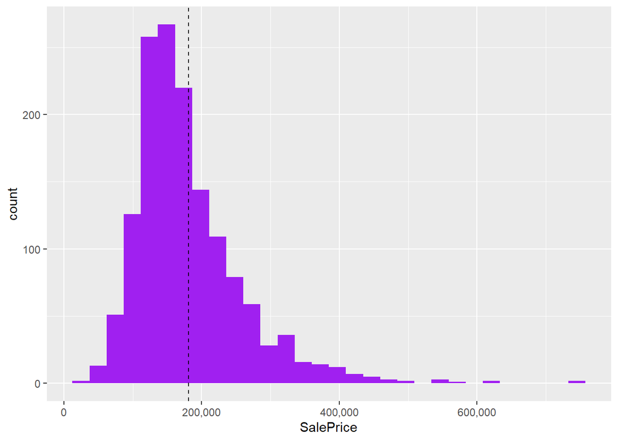

```r
all[1:1459, ] %>%
  ggplot(aes(x = SalePrice))+
  geom_histogram(fill = 'purple')+
  scale_x_continuous(labels = comma)+
  geom_vline(aes(xintercept = mean(SalePrice)), lty = 2)
```

- 20만 달러 언저리에서 평균이 형성되어 있군요
- 오른쪽으로 Skewed된 데이터이므로 높은 값의 이상치가 꽤 있는 것으로 보입니다. 차후 분석에 참고하겠습니다.

##### 2-1. 지역에 따른 집가격

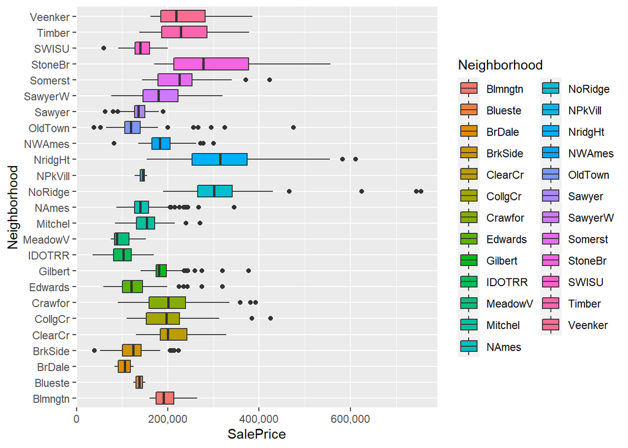

```r
all[1:1459, ] %>%
  ggplot(aes(x = Neighborhood, y = SalePrice, fill = Neighborhood))+
  geom_boxplot(position = 'dodge')+
  coord_flip() +
  scale_y_continuous(label = comma)
```

- **SWISU**는 아이오와 주립대의 남서쪽을 말합니다. 오히려 낮은 가격대이군요
- 그외 지역을 살펴봤을 때도, 딱히 대학교 주변이어서 더 좋은 가격을 형성하고 있지는 않았습니다.
- 만약 지역적인 요소로 좀더 특징을 나눌 수 있다면, 그 특징을 Flag로 사용하여 새로운 변수로 만들면 좋을 것 같습니다.

##### 2-2. 지역에 따른 방면적

대학가라면 보통 한국에서는 원룸촌이나 고시촌을 떠올리는 것 같습니다. 분명히 집의 전체 넓이와 가격은 상관관계가 있을 겁니다. 그럼 지역별로도 차이가 분명 있을까요?

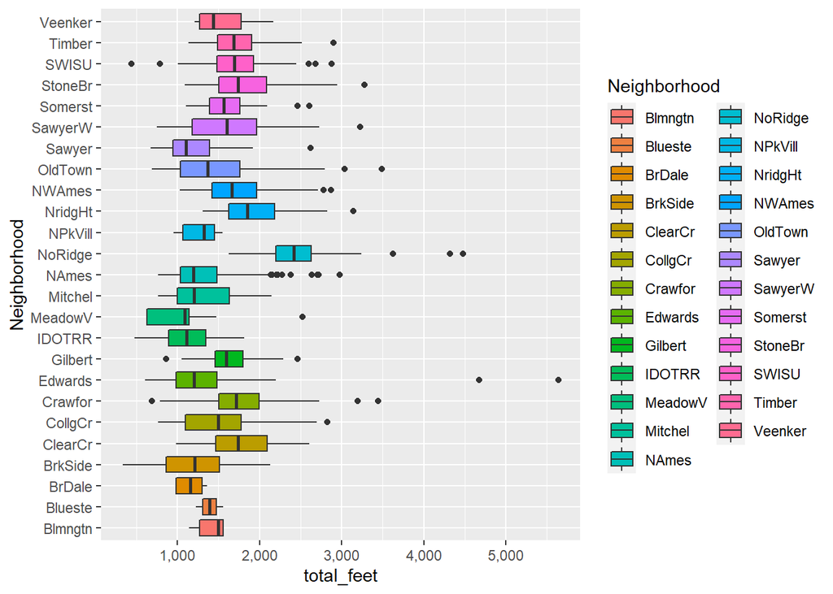

```r
all[1:1459, ] %>%
  mutate(total_feet = `1stFlrSF` + `2ndFlrSF`) %>%
  ggplot(aes(x = Neighborhood, y = total_feet, fill = Neighborhood))+
  geom_boxplot(position = 'dodge')+
  coord_flip() +
  scale_y_continuous(label = comma)
```

- **NoRidge**(Northridge)지역이 평균적으로 높은 넓이의 집을 가진 것 같습니다. 그래서인지 위에서 확인했듯 가격도 높은 편인 것 같네요. 아마 Ames City 내에서도 부촌이지 않을까요?

##### 2-3. 지역에 따른 방면적2

한국에서는 평단가라는 게 있죠? 여기서도 평단가를 한 번 계산해봤습니다.

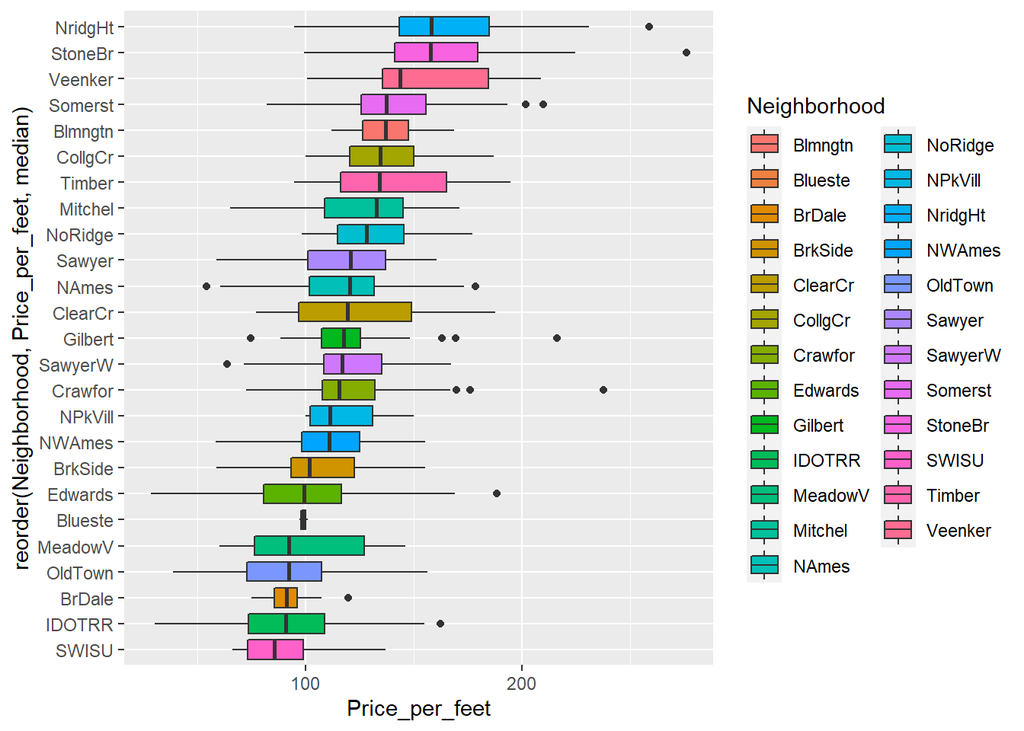

```r
all[1:1459, ] %>%
  mutate(total_feet = `1stFlrSF` + `2ndFlrSF`,
         Price_per_feet = SalePrice/total_feet) %>%
  ggplot(aes(x = reorder(Neighborhood,Price_per_feet,median ), y = Price_per_feet, fill = Neighborhood))+
  geom_boxplot(position = 'dodge')+
  coord_flip()
```

#### 3. 집의 여러 시설은 가격에 영향을 어떻게 미칠까?

미국 주택은 차고, 수영장, 덱, 포치 등 다양한 add-on 요소들이 있습니다. 단순히 방 몇 개, 화장실 몇 개 라는 것 보다 고려요소가 더 많아보입니다.

##### 3-1. 상관분석

상관분석을 통해서 여러 요소와 가격과의 관계를 잘 살펴볼 수 있을 것 같습니다.

```r
library(PerformanceAnalytics)
num_var <- c('LotArea', 'LotFrontage', 'YearBuilt', 'YearRemodAdd',
             'MasVnrArea', 'BsmtFinSF1', 'BsmtFinSF2', 'BsmtUnfSF', 'TotalBsmtSF',
             '1stFlrSF','2ndFlrSF','LowQualFinSF', 'GrLivArea', 'FullBath',
             'BedroomAbvGr','KitchenAbvGr','TotRmsAbvGrd','Fireplaces','GarageYrBlt',
             'GarageCars','GarageArea','WoodDeckSF','OpenPorchSF','OpenPorchSF','EnclosedPorch',
             '3SsnPorch','ScreenPorch','MiscVal','SalePrice')
```

- `PerformanceAnalytics` 패키지는 상관분석을 위해서 도입한 패키지입니다.
- num_var는 number type의 변수를 모아놓은 것입니다.

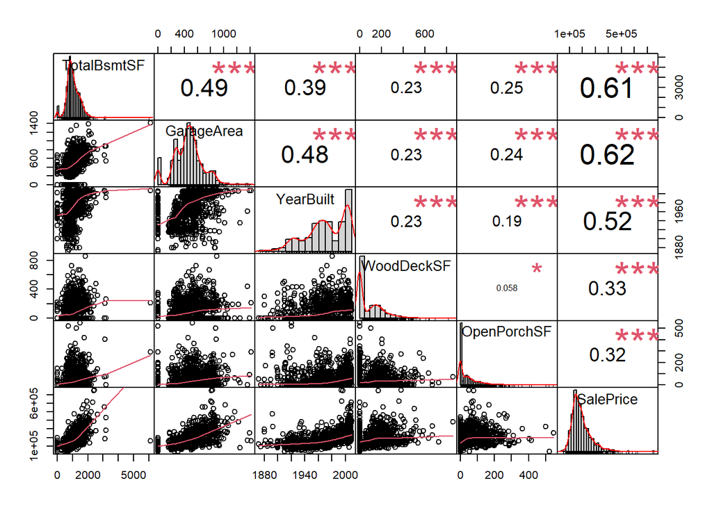

```r
all[1:1459, c('TotalBsmtSF','GarageArea','YearBuilt','WoodDeckSF','OpenPorchSF', 'SalePrice')] %>%
  chart.Correlation(histogram = T)
```

##### 3-2. 부대시설 세부

수영장을 한 번 살펴보겠습니다.

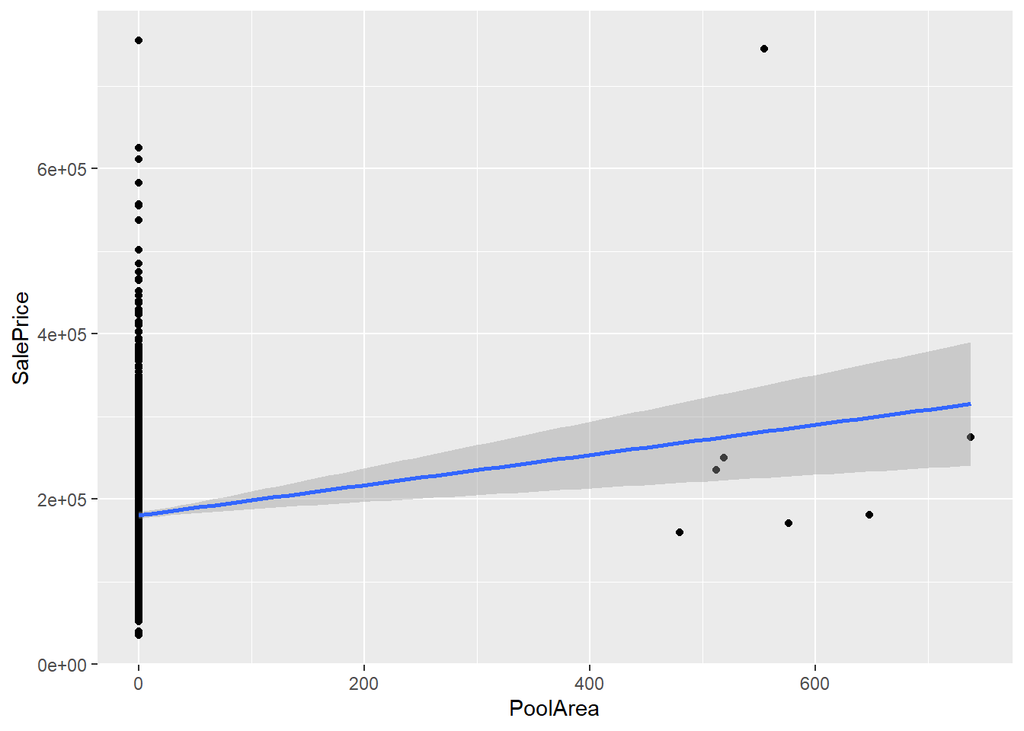

```r
all[1:1459, ] %>%
  ggplot(aes(x = PoolArea, y = SalePrice))+
  geom_point() +
  geom_smooth(method = 'lm', formula = y ~ x)
```

- 일단 데이터가 없는지, 아니면 실제로 수영장이 없는 건지 모르겠지만 분석용으로는 적당해 보이지 않습니다.
- 또는 수영장을 가지는 것이 해당 기후에서는 관리비용이 더 많이 들어서일 수도 있을 것 같네요.

Deck도 한 번 살펴볼게요.

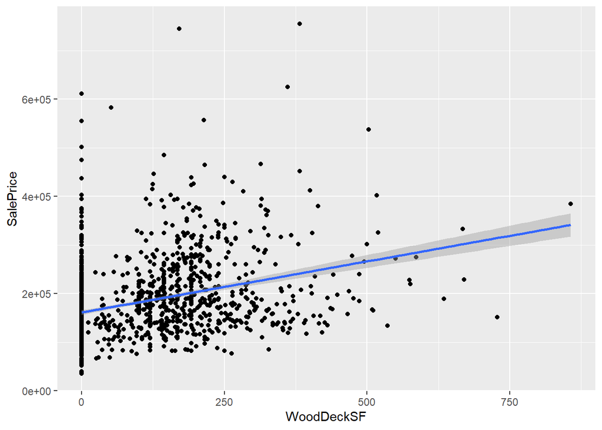

```r
all[1:1459, ] %>%
  ggplot(aes(x = WoodDeckSF, y = SalePrice))+
  geom_point() +
  geom_smooth(method = 'lm', formula = y ~ x)
```

##### 3-3. 집 면적과 가격

그러면 집 면적과 가격은 어떨까요?

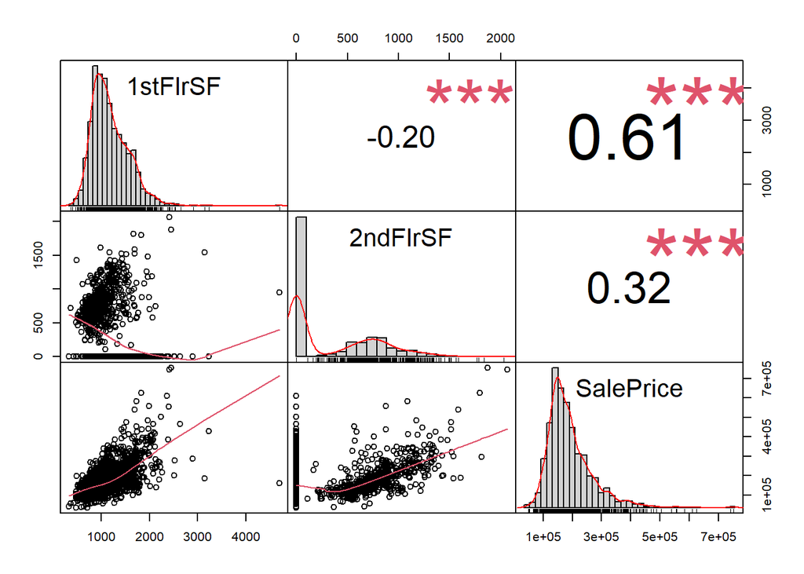

```r
all[1:1459, c('1stFlrSF','2ndFlrSF','SalePrice')] %>%
  chart.Correlation(histogram = T)
```

- 당연히 상관관계가 있군요. 하지만 1층의 넓이가 가격에 더 높은 영향을 주는 것으로 보입니다.
- 1층 넓이와 2층 넓이는 음의 관계에 있군요. 왜일까요?

#### 4. 리모델링 여부는 집 가격에 영향이 있는가?

YearBuilt 데이터를 보면 1900년 이전에 지어진 집도 있습니다. 한국에서는 아파트를 50년이상 사용하면 이미 철거를 논의하고 있겠지만, 미국 주택은 오래되어도 리모델링이 잘 된다면 여전히 좋은 가격에 팔린다고 하네요. 그래서 리모델 여부와 가격을 한 번 알아보겠습니다.

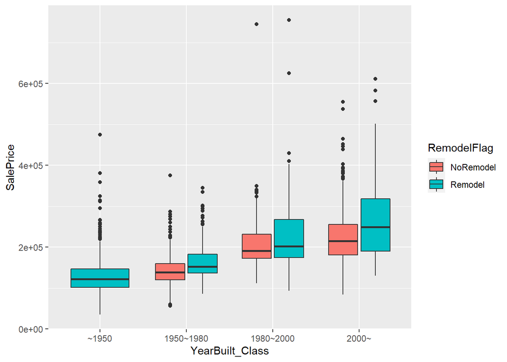

```r
all[1:1459, ] %>%
  mutate(RemodelFlag = as.factor(ifelse(YearBuilt == YearRemodAdd, 'NoRemodel','Remodel')),
         YearBuilt_Class = case_when(
           YearBuilt < 1950 ~ "~1950",
           YearBuilt < 1980 ~ "1950~1980",
           YearBuilt < 2000 ~ "1980~2000",
           T ~ "2000~"
         )) %>%
  ggplot(aes(x = YearBuilt_Class, y = SalePrice, fill = RemodelFlag))+
  geom_boxplot()
```

- 20년에서 30년을 기준으로 임의로 년도를 분할했습니다.
- 그래도 년도별로 대체로 리모델링 여부가 차이를 보이네요. 그리고 1950년대 이전의 집은 모두 리모델링을 한 것을 알 수 있습니다.
- 그리고 리모델링 한 집이 보통 위로 꼬리가 깁니다. 아마 협상의 여지가 있고, 보통은 높은 가격을 받았다는 의미인 것 같네요.
- 나중에 Feature Engineering에서 Flag로 만들면 분석에 더 도움이 될 것 같습니다.

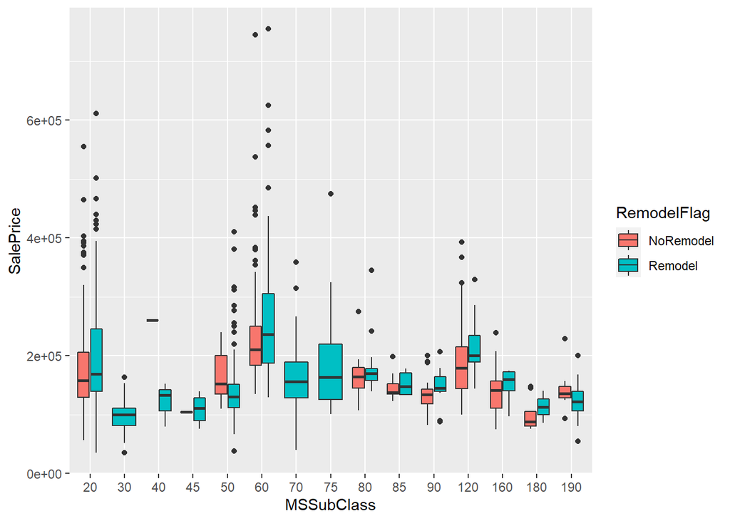

```r
all[1:1459, ] %>%
  mutate(RemodelFlag = as.factor(ifelse(YearBuilt == YearRemodAdd, 'NoRemodel','Remodel')),
         YearBuilt_Class = case_when(
           YearBuilt < 1950 ~ "~1950",
           YearBuilt < 1980 ~ "1950~1980",
           YearBuilt < 2000 ~ "1980~2000",
           T ~ "2000~"
         )) %>%
  ggplot(aes(x = MSSubClass, y = SalePrice, fill = RemodelFlag))+
  geom_boxplot()
```

- 집의 종류 별로도 가격을 세워봤습니다.
- 몇몇 종류의 집은 오히려 리모델링을 하지 않았을 때 더 좋은 가격을 보이는 집들도 있네요. 무슨 이유일까요?

#### 5. 판매 시점에 따른 가격 변화

2008년은 금융위기가 왔었고 집값이 많이 떨어졌습니다. 그래서 2008년에는 집값이 많이 떨어졌는지, 그리고 판매 시점별로 가격의 변화가 있는지 확인해보겠습니다.

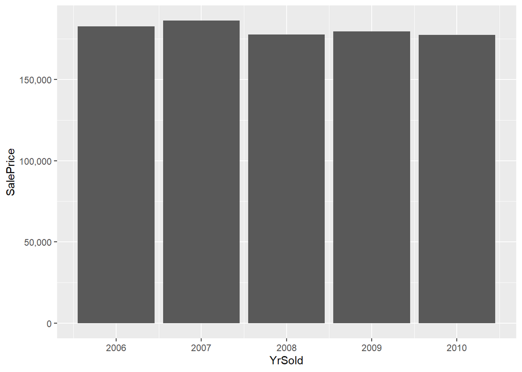

```r
all[1:1459, ] %>%
  group_by(YrSold) %>%
  summarise(SalePrice = mean(SalePrice)) %>%
  ggplot(aes(x = YrSold, y = SalePrice))+
  geom_col(position = 'dodge')+
  scale_y_continuous(labels = comma)
```

- 2008년 금융위기에 한 번 집값이 내렸을 것으로 예상했으나 의외로 많이 내리지는 않았군요.
- 그래도 오르기만 하는 집값의 특성 상 한 번 내린 년도가 있다는 것은 분석 관점에서 의의가 있어 보이네요.

그럼 월별로도 변화가 있는지 살펴볼까요?

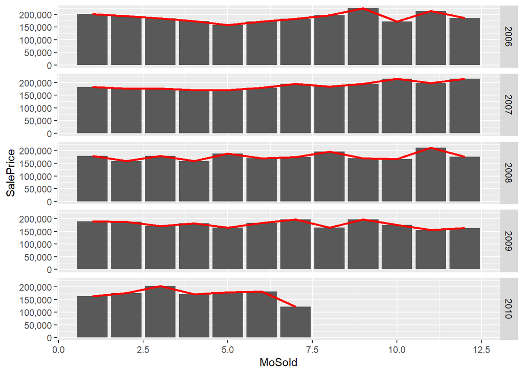

```r
all[1:1459, ] %>%
  group_by(YrSold, MoSold) %>%
  summarise(SalePrice = mean(SalePrice)) %>%
  ggplot(aes(x = MoSold, y = SalePrice))+
  geom_col(position = 'dodge')+
  geom_line(col = 'red', size = 1)+
  scale_y_continuous(labels = comma)+
  facet_grid(YrSold ~ .)
```

- 딱히 월별로도 특징적인 변화가 있는 것 같지 않습니다.

## 결론

제가 머신러닝을 위한 EDA를 수행하면서 느낀 점은 아래와 같습니다.

**1. 변수가 많을수록 EDA의 경우의 수가 많아서 힘들다** 변수가 많으면 그만큼 고려해야 할 경우의 수가 많아서 어려운 것 같습니다. 특히 80개 정도 되는 변수 속에서 각 변수의 특성을 파악하고 EDA의 아이디어를 잡는 데 꽤 많은 시각이 걸린 것 같네요. 이럴 때 사용할 수 있는 정형화된 일련의 접근 방식이 있다면 좋을 것 같습니다. 보통은 상관계수로 많이 접근하는 것 같아요. 여러분의 의견은 어떤가요?

**2. 적절한 미국 부동산 지식이 EDA의 접근 가능성을 높임** 저는 미국 부동산 유튜브를 조금 참조했습니다. 그 결과 오래된 집이어도 리모델링이 잘 되어 있다면 높은 가격을 받을 수 있다는 사실을 알게 되었네요. 이게 도메인의 힘인 것 같습니다. 데이터 분석을 위해서는 유효한 질문이 필요하고, 그 질문은 사실 분석가의 아이디어 속에 있는 것이군요..

**3. EDA의 결과는 Feature Engineering과 이어져야 큰 의미가 있는걸까?** 결국 저희는 머신러닝을 통해서 모델링을 할 예정이잖아요? 시각화로 데이터를 보는 것 자체가 중요하다기 보다는 이를 Feature Engineering으로 새로운 변수를 만들어 모델링에 심을 수 있는 게 더욱 중요하다는 생각이 들었습니다. 그런 의미에서 머신러닝에서의 EDA는 정말 Feature Engineering의 전단계라는 생각이 들었네요.

여기까지 제가 정리한 자료입니다. 앞으로 머신러닝닝 모델을 진행하면서 더 많이 배우기를 기대해봅니다 :)